# Project 1

Author

Franchesca Garcia, Kaatje Matthews-vanKoetsveld, Jett Palmer

# Checkpoint 1

```r
library(tidyverse)
library(gt)
democracy_data <- readr::read_csv('https://raw.githubusercontent.com/rfordatascience/tidytuesday/main/data/2024/2024-11-05/democracy_data.csv')
```

## Data Context

The dataset is read in from Tidy Tuesday on GitHub and was curated by Jon Harmon. This dataset is an updated version of the [pacl](https://xmarquez.github.io/democracyData/reference/pacl.html#source) dataset, described in J. A. Cheibub, J. Gandhi, and J. R. Vreeland. “Democracy and Dictatorship Revisited”. In: Public Choice 143.1-2 (2009), pp. 67-101. DOI: 10.1007/s11127-009-9491-2.

The data describes the regime types of countries around the world between the years 1950 and 2020. Each observation (row) is a country and year and contains information about that country’s government regime in said year. Many of the variables recorded are booleans that indicate the political system or political rights of the country such as `is_communist` or `is_presidential`.

These data are important to measure and evaluate the differences across regimes, and evaluate changes in democracies on a global scale.

## Data Cleaning

The cleaning script for the data is in the code chunk below. The orginal pacl data is being cleaned and updated in this script.

```r
# Data from the package {democracyData}
# install.packages("pak")
# pak::pak("xmarquez/democracyData")
library(democracyData)
library(tidyverse)

democracy_data <-
  democracyData::pacl_update |>
  janitor::clean_names() |>
  dplyr::select(
    "country_name" = "pacl_update_country",
    "country_code" = "pacl_update_country_isocode",
    "year",
    "regime_category_index" = "dd_regime",
    "regime_category" = "dd_category",
    "is_monarchy" = "monarchy",
    "is_commonwealth" = "commonwealth",
    "monarch_name",
    "monarch_accession_year" = "monarch_accession",
    "monarch_birthyear",
    "is_female_monarch" = "female_monarch",
    "is_democracy" = "democracy",
    "is_presidential" = "presidential",
    "president_name",
    "president_accesion_year" = "president_accesion",
    "president_birthyear",
    "is_interim_phase" = "interim_phase",
    "is_female_president" = "female_president",
    "is_colony" = "colony",
    "colony_of",
    "colony_administrated_by",
    "is_communist" = "communist",
    "has_regime_change_lag" = "regime_change_lag",
    "spatial_democracy",
    "parliament_chambers" = "no_of_chambers_in_parliament",
    "has_proportional_voting" = "proportional_voting",
    "election_system",
    "lower_house_members" = "no_of_members_in_lower_house",
    "upper_house_members" = "no_of_members_in_upper_house",
    "third_house_members" = "no_of_members_in_third_house",
    "has_new_constitution" = "new_constitution",
    "has_full_suffrage" = "fullsuffrage",
    "suffrage_restriction",
    "electoral_category_index" = "electoral",
    "spatial_electoral",
    "has_alternation" = "alternation",
    "is_multiparty" = "multiparty",
    "has_free_and_fair_election" = "free_and_fair_election",
    "parliamentary_election_year",
    "election_month" = "election_month_year",
    "has_postponed_election" = "postponed_election"
  ) |>
  dplyr::mutate(
    election_month = dplyr::na_if(.data$election_month, "?")
  ) |>
  tidyr::separate_wider_regex(
    "election_month",
    patterns = c(
      election_month = "\\D+",
      election_year = "\\d{4}$"
    ),
    too_few = "align_start"
  ) |>
  dplyr::mutate(
    electoral_category = dplyr::case_match(
      .data$electoral_category_index,
      0 ~ "no elections",
      1 ~ "single-party elections",
      2 ~ "non-democratic multi-party elections",
      3 ~ "democratic elections"
    ),
    .after = "electoral_category_index"
  ) |>
  dplyr::mutate(
    election_month = stringr::str_squish(.data$election_month),
    dplyr::across(
      c(
        tidyselect::ends_with("_index"),
        tidyselect::contains("year"),
        tidyselect::ends_with("_members"),
        "parliament_chambers"
      ),
      as.integer
    ),
    dplyr::across(
      c(
        tidyselect::starts_with("is_"),
        tidyselect::starts_with("has_")
      ),
      as.logical
    )
  )
```

The first section of the data cleaning process selects 41 columns from the pacl dataset, after using janitor package to clean the names of the variables. In this select statement, the majority of the columns are renamed to a more informative column name. Most of the logical data types (True or False) get the added `is_` or `has_` prefix and the other renamed columns add useful variable information such as `monarch_accession_year` instead of `monarch_accession`.

The next section of cleaning mutates the variables. The “?” value in `election_month` is replaced with NA’s. `election_month` is split into two columns, on for the month and one for the year of the election (originally in the same variable). `election_month` also has the whitespace removed. A new character variable, `electoral_category` is created using the definitions from the `electoral_category_index`.

Lastly, any of the of the index, year, or members variables along with `parliament_chambers` are converted to integer datatypes. Then, all the `is_` or `has_` variables are converted to logical datatypes.

## Research Questions from Data

1. How has president age changed over time and is there a difference for female presidents vs. male presidents?
2. How long on average does it take countries that stopped being democratic to return to democracy?

## Research Questions with Supplemental Data

1. How does happiness score differ by regime type? Is there a difference in happiness between different types of democratic regimes?
2. Do more educated countries have more democratic regimes?
3. How does the distribution of populations compare between democratic and non-democratic countries.

## Visualization Sketches

1. For RQ 1 from these Data

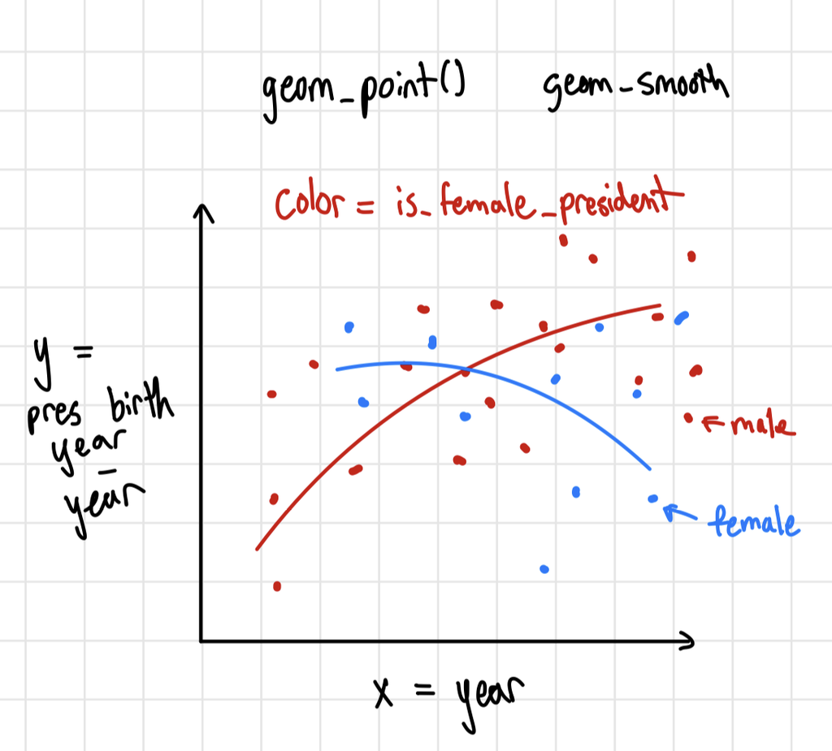

2. For RQ 3 from supplemental data

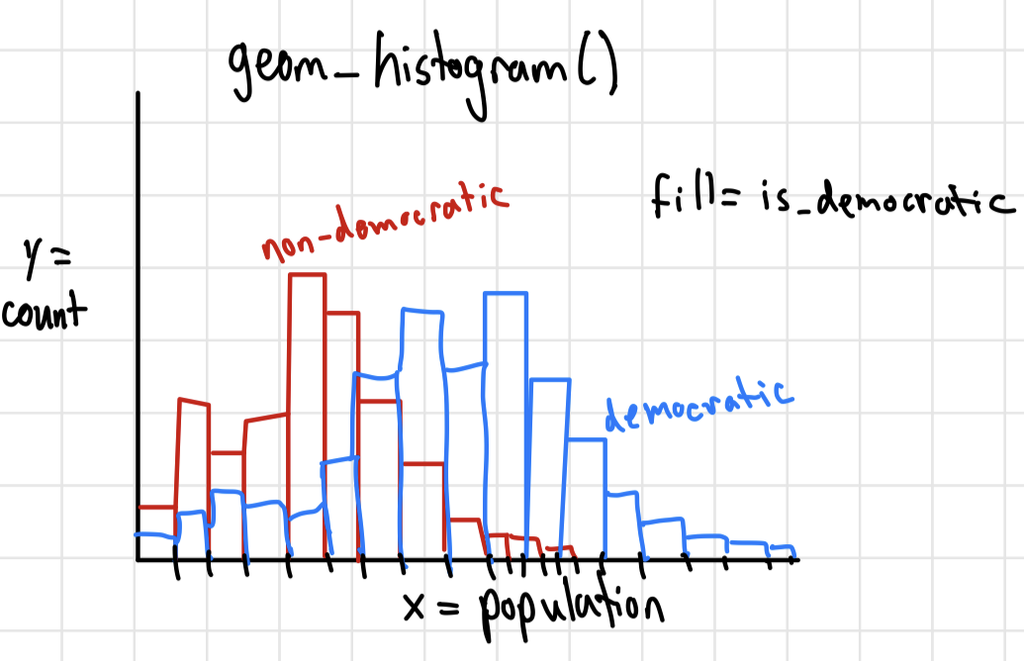

# Checkpoint 2

## Unmodified data summaries

### Count of Regimes and Percent of Dictatorships Per Country

*no new columns, requires custom function and iteration*

```r
# Calculates the number of regime changes for a given country
count_regimes <- function(country) {

  democracy_data |>
    filter(country_code == country) |>
    arrange(year) |>
    mutate(prev_regime = lag(regime_category)) |>
    filter(year == min(year) | regime_category != prev_regime) |>
    nrow()

}

# Calculates the number of regimes that were dictatorships for a given country
# Regime index of 3, 4, or 5 indicates a dictatorship
count_dictatorships <- function(country) {

  democracy_data |>
    filter(country_code == country) |>
    arrange(year) |>
    mutate(prev_regime = lag(regime_category)) |>
    filter(year == min(year) | regime_category != prev_regime,
           regime_category_index >= 3) |>
    nrow()

}


democracy_data |>
  distinct(country_code, country_name) |>
  # Uses map to iteratively apply the custom functions above and calculates the
  # proportion of regimes that were/are dictatorships in each country
  mutate(n_regimes = map_dbl(country_code, count_regimes),
         n_dicts = map_dbl(country_code, count_dictatorships),
         prop_dict = n_dicts/n_regimes) |>
  select(country_name, n_regimes, prop_dict) |>
  arrange(desc(n_regimes)) |>
  gt() |>
  cols_label(country_name = "Country",
             n_regimes = "Number of Regimes",
             prop_dict = "Percent Dictatorship") |>
  tab_style(cell_text(weight = "bold"),
            locations = cells_column_labels(everything())) |>
  fmt_percent(columns = prop_dict) |>
  data_color(prop_dict,
             palette = "Blues") |>
  tab_caption(caption = md("Counts of regimes per country, with the percent of regimes that were dictatorships."))
```

Counts of regimes per country, with the percent of regimes that were dictatorships.

| Country | Number of Regimes | Percent Dictatorship |
| --- | --- | --- |
| Thailand | 10 | 60.00% |
| Argentina | 9 | 44.44% |
| Bangladesh | 9 | 66.67% |
| Burundi | 9 | 66.67% |
| Guinea-Bissau | 9 | 66.67% |
| Pakistan | 9 | 55.56% |
| Anguilla | 8 | 0.00% |
| Bolivia | 8 | 75.00% |
| Cambodia | 8 | 100.00% |
| Ghana | 8 | 37.50% |
| Honduras | 8 | 62.50% |
| Lebanon | 8 | 87.50% |
| Niger | 8 | 50.00% |
| Peru | 8 | 50.00% |
| Sudan | 8 | 50.00% |
| Central African Republic | 7 | 71.43% |
| Comoros | 7 | 57.14% |
| Ecuador | 7 | 57.14% |
| Fiji | 7 | 71.43% |
| Guatemala | 7 | 42.86% |
| Guyana | 7 | 28.57% |
| Maldives | 7 | 42.86% |
| Sierra Leone | 7 | 57.14% |
| Turks and Caicos | 7 | 0.00% |
| Uganda | 7 | 71.43% |
| Benin | 6 | 66.67% |
| Congo, Republic of | 6 | 50.00% |
| Grenada | 6 | 16.67% |
| Laos | 6 | 83.33% |
| Lesotho | 6 | 50.00% |

[output cut: 178 more lines]

### Democratic Principals by Regime Categories

*no new columns, requires custom function and no iteration*

```r
# regimes is optional input as a vector of regime categories
# the default argument looks at the 4 we wish to compare
summarize_regimes <- function(regimes = c("Civilian dictatorship",
                                          "Parliamentary democracy",
                                          "Military dictatorship",
                                          "Presidential democracy")) {

  # For each regime type the proportion of observations with each democratic
  # principle is calculated
  democracy_data |>
    filter(regime_category %in% regimes) |>
    group_by(regime_category) |>
    summarize(
      n = n(),
      prop_demo = sum(is_democracy, na.rm = TRUE) / n,
      prop_suffrage = sum(has_full_suffrage, na.rm = TRUE) / n,
      prop_multiparty = sum(is_multiparty, na.rm = TRUE) / n,
      prop_free_fair = sum(has_free_and_fair_election, na.rm = TRUE) / n,
      prop_alternation = sum(has_alternation, na.rm = TRUE) / n
    ) |>
    gt() |>
    cols_label(
      regime_category = "Regime",
      n = "Number of Observations",
      prop_demo = "Democratic",
      prop_suffrage = "Full Voting Rights",
      prop_multiparty = "Multi-Party Elections",
      prop_free_fair = "Free & Fair Elections",
      prop_alternation = "Rotating Top Office"
    ) |>
    tab_style(
      cell_text(weight = "bold"),
      locations = cells_column_labels(everything())
    ) |>
    fmt_percent(columns = -c(n, regime_category)) |>
    tab_caption(
      caption = md("Percent of observations demonstrating democratic principals, by regime category")
    ) |>
    tab_spanner(
      label = "Democratic Principals Represented (% Observations)",
      columns = -c(n, regime_category)
    ) |>
    data_color(
      columns = -c(n, regime_category),
      palette = "Blues"
    )
}

summarize_regimes()
```

Percent of observations demonstrating democratic principals, by regime category

| Regime | Number of Observations | Democratic Principals Represented (% Observations) Democratic | Democratic Principals Represented (% Observations) Full Voting Rights | Democratic Principals Represented (% Observations) Multi-Party Elections | Democratic Principals Represented (% Observations) Free & Fair Elections | Democratic Principals Represented (% Observations) Rotating Top Office |
| --- | --- | --- | --- | --- | --- | --- |
| Civilian dictatorship | 2998 | 0.03% | 93.70% | 52.43% | 3.14% | 0.47% |
| Military dictatorship | 1892 | 0.05% | 90.91% | 40.12% | 0.26% | 0.05% |
| Parliamentary democracy | 2660 | 99.89% | 97.26% | 99.89% | 99.89% | 99.89% |
| Presidential democracy | 1509 | 99.87% | 92.05% | 99.87% | 99.87% | 99.67% |

## Modified data summaries

### Percent of Independent Countries Over the Years

*new columns, requires custom function and iteration*

```r
# Checks if the regime is not independent via its regime category
is_not_ind <- function(regime_category_index, regime_category) {

  is.na(regime_category_index) |
    regime_category %in% c("Colony",
                           "British Overseas Territory")

}

# Uses map to iteratively apply the not independent function above
democracy_data |>
  mutate(not_independent = map2_lgl(regime_category_index,
                                    regime_category,
                                    is_not_ind)) |>
  # For each year in the data, the counts and proportion of independent contries
  # are calculated
  group_by(year) |>
  summarise(
    ind_count = sum(!not_independent),
    not_ind_count = sum(not_independent)
    ) |>
  mutate(prop_ind = ind_count/(ind_count + not_ind_count)) |>
  select(year, prop_ind, ind_count, not_ind_count) |>
  gt() |>
  cols_label(year = "Year",
             prop_ind = "Proportion of Independent Countries",
             ind_count = "Number of Independent Countries",
             not_ind_count = "Number of Non-Independent Countries") |>
  tab_style(cell_text(weight = "bold"),
            locations = cells_column_labels(everything())) |>
  data_color(prop_ind,
             palette = "Blues") |>
  fmt_percent(columns = prop_ind) |>
  tab_caption(caption = md("Yearly percent of recorded countries that were independent."))
```

Yearly percent of recorded countries that were independent.

| Year | Proportion of Independent Countries | Number of Independent Countries | Number of Non-Independent Countries |
| --- | --- | --- | --- |
| 1950 | 43.27% | 90 | 118 |
| 1951 | 43.27% | 90 | 118 |
| 1952 | 43.75% | 91 | 117 |
| 1953 | 43.75% | 91 | 117 |
| 1954 | 43.75% | 91 | 117 |
| 1955 | 43.75% | 91 | 117 |
| 1956 | 45.19% | 94 | 114 |
| 1957 | 45.67% | 95 | 113 |
| 1958 | 46.15% | 96 | 112 |
| 1959 | 46.63% | 97 | 111 |
| 1960 | 50.48% | 105 | 103 |
| 1961 | 55.77% | 116 | 92 |
| 1962 | 56.73% | 118 | 90 |
| 1963 | 59.62% | 124 | 84 |
| 1964 | 60.58% | 126 | 82 |
| 1965 | 62.98% | 131 | 77 |
| 1966 | 63.94% | 133 | 75 |
| 1967 | 65.38% | 136 | 72 |
| 1968 | 66.35% | 138 | 70 |
| 1969 | 67.31% | 140 | 68 |
| 1970 | 67.79% | 141 | 67 |
| 1971 | 68.75% | 143 | 65 |
| 1972 | 69.23% | 144 | 64 |
| 1973 | 69.23% | 144 | 64 |
| 1974 | 70.67% | 147 | 61 |
| 1975 | 71.15% | 148 | 60 |
| 1976 | 74.52% | 155 | 53 |
| 1977 | 75.00% | 156 | 52 |
| 1978 | 75.00% | 156 | 52 |
| 1979 | 76.92% | 160 | 48 |
| 1980 | 77.88% | 162 | 46 |
| 1981 | 78.37% | 163 | 45 |
| 1982 | 79.33% | 165 | 43 |
| 1983 | 79.33% | 165 | 43 |
| 1984 | 79.81% | 166 | 42 |
| 1985 | 79.81% | 166 | 42 |
| 1986 | 79.81% | 166 | 42 |
| 1987 | 80.77% | 168 | 40 |
| 1988 | 80.77% | 168 | 40 |
| 1989 | 80.77% | 168 | 40 |
| 1990 | 81.25% | 169 | 39 |
| 1991 | 89.90% | 187 | 21 |
| 1992 | 89.90% | 187 | 21 |
| 1993 | 90.38% | 188 | 20 |
| 1994 | 90.38% | 188 | 20 |
| 1995 | 90.87% | 189 | 19 |
| 1996 | 90.87% | 189 | 19 |
| 1997 | 90.87% | 189 | 19 |
| 1998 | 90.87% | 189 | 19 |
| 1999 | 90.87% | 189 | 19 |
| 2000 | 90.87% | 189 | 19 |
| 2001 | 90.87% | 189 | 19 |
| 2002 | 91.35% | 190 | 18 |
| 2003 | 91.35% | 190 | 18 |
| 2004 | 91.35% | 190 | 18 |
| 2005 | 91.35% | 190 | 18 |
| 2006 | 91.83% | 191 | 17 |
| 2007 | 91.83% | 191 | 17 |
| 2008 | 91.83% | 191 | 17 |
| 2009 | 91.83% | 191 | 17 |
| 2010 | 91.83% | 191 | 17 |
| 2011 | 92.31% | 192 | 16 |
| 2012 | 92.31% | 192 | 16 |
| 2013 | 92.31% | 192 | 16 |
| 2014 | 92.31% | 192 | 16 |
| 2015 | 92.31% | 192 | 16 |
| 2016 | 92.31% | 192 | 16 |
| 2017 | 92.31% | 192 | 16 |
| 2018 | 92.31% | 192 | 16 |
| 2019 | 92.31% | 192 | 16 |
| 2020 | 91.83% | 191 | 17 |

### Forms of Governance by World Region

*new column for region, no iteration or custom function*

```r
library(countrycode)
democracy_data <- democracy_data |>
  # Creates the region column using the countrycode package
  mutate(region = countrycode(country_code,
                              origin = 'iso3c',
                              destination = 'region',
                              # Custom matches for the codes that don't find match
                              custom_match = c('ZAR' = 'Sub-Saharan Africa',
                                               'GER' = 'Europe & Central Asia',
                                               'NUR' = 'East Asia & Pacific',
                                               'PRI' = 'Latin America & Caribbean',
                                               'ROM' = 'Europe & Central Asia'
                                               )
                              )
         )

democracy_data |>
  group_by(region) |>
  # Proportions of each form of governance
  summarize(n = n(),
            prop_demo = sum(is_democracy, na.rm = TRUE)/n,
            prop_pres = sum(is_presidential, na.rm = TRUE)/n,
            prop_mon = sum(is_monarchy, na.rm = TRUE)/n,
            prop_comw = sum(is_commonwealth, na.rm = TRUE)/n,
            prop_colon = sum(is_colony, na.rm = TRUE)/n,
            prop_comm = sum(is_communist, na.rm = TRUE)/n
            ) |>
  gt() |>
  cols_label(region = "World Region",
             n = "Number of Observations",
             prop_demo = "Percent Democratic",
             prop_pres = "Percent Presidential",
             prop_mon = "Percent Monarchy",
             prop_comw = "Percent Commonwealth",
             prop_colon = "Percent Colony",
             prop_comm = "Percent Communist",
             ) |>
  tab_style(cell_text(weight = "bold"),
            locations = cells_column_labels(everything())) |>
  fmt_percent(columns = -c(n, region)) |>
  tab_caption(caption = md("Percent of observations under each form of governance, by World Region.")) |>
  tab_spanner(label = "Governance Type (%)",
              columns = -c(n, region)) |>
  data_color(columns = -c(n, region),
             palette = "Blues")
```

Percent of observations under each form of governance, by World Region.

| World Region | Number of Observations | Governance Type (%) Percent Democratic | Governance Type (%) Percent Presidential | Governance Type (%) Percent Monarchy | Governance Type (%) Percent Commonwealth | Governance Type (%) Percent Colony | Governance Type (%) Percent Communist |
| --- | --- | --- | --- | --- | --- | --- | --- |
| East Asia & Pacific | 2556 | 44.25% | 30.83% | 29.58% | 26.84% | 24.96% | 11.62% |
| Europe & Central Asia | 3621 | 56.84% | 28.11% | 21.84% | 3.62% | 2.26% | 32.75% |
| Latin America & Caribbean | 2982 | 76.46% | 55.06% | 35.71% | 19.28% | 32.13% | 3.12% |
| Middle East & North Africa | 1420 | 12.39% | 33.87% | 46.06% | 3.94% | 7.96% | 0.00% |
| North America | 213 | 93.90% | 33.33% | 66.67% | 33.33% | 33.33% | 0.00% |
| South Asia | 568 | 41.37% | 29.75% | 29.40% | 48.42% | 2.82% | 2.46% |
| Sub-Saharan Africa | 3408 | 18.37% | 67.78% | 6.31% | 26.91% | 19.42% | 5.96% |

# Checkpoint 3

## Data Descriptions

### World Happiness Report

With the first World Happiness report released on April 1st of 2012 by the United Nations General Assembly, this report has now captured self-perception data on global happiness for a near-consecutive 13 years. Today, the survey is supported by the University of Oxford and Gallup and represents over 140 countries. The report was established by the United Nations with the purpose of “giv[ing] more importance to happiness and well-being in determining how to achieve and measure social and economic development” (World Happiness Report). Each year, more than 100,000 people take the survey and are asked a happiness ranking question that is translated into their native language.

### World Bank Group

World Bank Group is a collection of internationally-operating organizations that aim to reduce global poverty through sustainable development and financing. Their operations and mission are highly data-driven, and they provide a breadth of open-source, global welfare data to the public via their API. Most datasets date back several decades, represent hundreds of countries, and vary on completeness. Datasets associated with their products and services (e.g., lending portfolios, asset management) are created and updated internally. Other global development data are sourced via World Bank partners, including governments, international agencies, regional development banks, donors, and others. We accessed country-level data on population, life-expectancy, and education-related variables.

## Webscraping World Happiness Report

link = https://en.wikipedia.org/wiki/World_Happiness_Report

```r
library(rvest)
```

```r
#Reads the html from the World Happiness Report Wikipedia page
WHR <- read_html("https://en.wikipedia.org/wiki/World_Happiness_Report")
```

```r
# There are 39 tables, so we need to reduce to the ones we want
WHR |>
  html_elements("table") |>
  length()
```

```
[1] 39
```

```r
# Get the header nodes
headers <- WHR |>
  html_elements("h3")
header_text <- headers |>
  html_text(trim = TRUE)

# Creates the patterns to match the header nodes
years <- 2013:2025
targets <- paste0(years, " report")

# Only keeps the report headedrs
target_idx <- str_detect(header_text, str_c(targets, collapse = "|"))
target_headers <- headers[target_idx]
target_labels <- header_text[target_idx]


# Function takes table following the specified header.
get_WHR_table <- function(header) {
  header |>
    html_element(xpath = "following::table[1]") |>
    html_table(fill=TRUE)
}

# Retreive tables
WHR_tables <- target_headers |>
  map(get_WHR_table)
```

```r
# Add year column
clean_whr <- function(df, year) {
  if (year == 2016) {
    # Third row is the real column names
    colnames(df) <- as.character(unlist(df[3, ]))
    # drop the 2 rows with messy column names
    df <- df[-c(1, 2, 3), 1:4]
  } else {
    # Second row is the real column names
    colnames(df) <- as.character(unlist(df[2, ]))
    # drop the 2 rows with messy column names
    df <- df[-c(1, 2), ]
    # drop extra empty columns
    df <- df[, !is.na(colnames(df))]
  }

  # reset row names
  rownames(df) <- NULL
  # Add year as a column
  df <- df |>
    mutate(year = as.integer(year))

  # Year specific problems
  if (year == 2013) {
    df |>
      rename(country_name = Country,
             `Overall rank` = `Rank[61]`,
             Score = Happiness)
  } else if (year == 2016) {
    df |>
      rename(country_name = Country,
             `Overall rank` = `Overall Rank[58][59]`)
  } else if (year ==  2017) {
    df |>
      filter_out(Country %in% c("Europe[a]", "World")) |>
      rename(country_name = Country,
             `Overall rank` = `Overall Rank`)
  } else if (year == 2023) {
    df |>
      mutate(`Country or region` = str_remove_all(`Country or region`,
                                                   "\\*")) |>
      rename(country_name = `Country or region`) |>
      slice(-n())
  } else {
    df |>
      rename(country_name = `Country or region`)
  }
}

# runs function on the list of dataframes to clean
# Different tables have different issues
years <- c(2025, 2024, 2023, 2022, 2020, 2019, 2018, 2017, 2016, 2013)
WHR_tables2 <- map2(WHR_tables, years, .f = clean_whr)
```

```r
#Bind the rows of all the individual year tables
WHR_table <- bind_rows(WHR_tables2)

#Joins the world happiness data to the democracy data on country and year
democracy_WHR_data <- democracy_data |>
  left_join(WHR_table,
            by = c("country_name",
                   "year")) |>
  mutate(across(`Overall rank`:`Generosity`, as.numeric))
```

## Summary table of happiness by regime category

```r
# Table numeric summary of happiness score by regime.
democracy_WHR_data |>
  group_by(regime_category) |>
  filter_out(is.na(Score)) |>
  summarize(n=n(),
            avg_happy = mean(Score, na.rm=TRUE),
            sd_happy = sd(Score, na.rm=TRUE),
            min_happy = min(Score, na.rm=TRUE),
            med_happy = median(Score, na.rm=TRUE),
            max_happy = max(Score, na.rm=TRUE)
  ) |>
  filter(n >= 10) |>
  arrange(desc(avg_happy)) |>
  gt() |>
  cols_label(regime_category = "Regime",
             n = "Number of Observations",
             avg_happy = "Average Happiness Score",
             sd_happy = "Standard Deviation Happiness Score",
             min_happy = "Minimum Happiness Score",
             med_happy = "Median Happiness Score",
             max_happy = "Maximum Happiness Score"
             ) |>
  tab_style(cell_text(weight = "bold"),
            locations = cells_column_labels(everything())) |>
  tab_caption(caption = md("Happiness Score Summary by Regime Category")) |>
  tab_footnote(footnote = "Happiness Score scraped from World Happiness Report
  Wikipedia page, Scores are out of 10") |>
  data_color(columns = -c(n, regime_category),
             palette = "Blues")
```

Happiness Score Summary by Regime Category

| Regime | Number of Observations | Average Happiness Score | Standard Deviation Happiness Score | Minimum Happiness Score | Median Happiness Score | Maximum Happiness Score |
| --- | --- | --- | --- | --- | --- | --- |
| Parliamentary democracy | 181 | 6.257199 | 0.9849157 | 3.573 | 6.3100 | 7.693 |
| Royal dictatorship | 41 | 6.049415 | 0.6296753 | 4.633 | 6.2270 | 7.144 |
| Presidential democracy | 177 | 5.675395 | 1.0238260 | 3.410 | 5.7970 | 7.650 |
| Mixed democratic | 130 | 5.608215 | 1.1030772 | 3.479 | 5.4440 | 7.809 |
| Civilian dictatorship | 210 | 4.923481 | 0.8164028 | 2.567 | 5.0005 | 7.342 |
| Military dictatorship | 58 | 3.956069 | 0.8541405 | 2.693 | 3.7080 | 6.474 |

Happiness Score scraped from World Happiness Report Wikipedia page, Scores are out of 10

## API

World Bank variables of interest:

**Population** - Total population SP.POP.TOTL - Population growth SP.POP.GROW - Birth rate SP.DYN.CBRT.IN - Death rate SP.DYN.CDRT.IN - Life expectancy male SP.DYN.LE00.MA.IN - Life expectancy female SP.DYN.LE00.FE.IN

**Education** - School enrollment primary SE.PRM.ENRR - School enrollment secondary SE.SEC.ENRR - School enrollment tertiary SE.TER.ENRR

```r
library(httr)
library(tidyjson)
library(jsonlite)
library(tidyverse)
library(glue)
```

```r
# Create function that accesses country-level variable from World Bank API

get_indicator <- function(country_code, indicator_code) {

  url <- glue("https://api.worldbank.org/v2/country/{country_code}/indicator/{indicator_code}?format=json&per_page=100")

  if(httr::status_code(GET(url)) == 200){

  json <- GET(url) |>
    (\(x) x$content)() |>
    rawToChar() |>
    fromJSON()

    if (length(json) < 2 || is.null(json[[2]])) {
      return(NULL)
    }

    if(is.data.frame(json[[2]])) {
      indicator_name = str_to_snake(json[[2]]$indicator$value[1])

      json[[2]] |>
      select(country_code = countryiso3code,
             year = date,
             value) |>
      mutate(year = as.integer(year),
             indicator = indicator_name)
    }
    else{
      return(NULL)
    }
  }
  else{
    return(NULL)
  }
}
```

The following code up to Checkpoint 4 will not evaluate due to long runtimes.

```r
# Create vectors for unique country codes and variables of interest based on World Bank variable codes

country_codes <- democracy_data$country_code |>
  unique()

indicators <- c("SP.POP.TOTL",
                "SP.POP.GROW",
                "SP.DYN.CBRT.IN",
                "SP.DYN.CDRT.IN",
                "SP.DYN.LE00.MA.IN",
                "SP.DYN.LE00.FE.IN",
                "SE.PRM.ENRR",
                "SE.SEC.ENRR",
                "SE.TER.ENRR")

# Iterate function over countries and variables of interest

people_data <- list()

for (c in country_codes) {
  for (i in indicators) {

    temp <- get_indicator(c, i)

    if (!is.null(temp)) {
      people_data[[length(people_data) + 1]] <- temp
    }
  }
}

people <- bind_rows(people_data)
```

```r
people <- people |>
  pivot_wider(names_from = indicator,
              values_from = value)

# Join people data, happiness data, and original data

democracy_data <- democracy_WHR_data |>
  left_join(
    people,
    by = c("country_code", "year")
  )
```

```r
# Create set of "default regimes" which consist of the top five most common

default_regimes <- c(
  "Parliamentary democracy",
  "Presidential democracy",
  "Mixed democratic",
  "Civilian dictatorship",
  "Military dictatorship"
)

# Create graph of life expectancy over time by regime category (top 5)

# This data wrangling step allows for the color gradient to match the
# life expectancy order and computes the averages

plot_data <- democracy_data |>
  filter(regime_category %in% default_regimes) |>
  mutate(
    avg_life_expectancy = (
      life_expectancy_at_birth_male_years +
      life_expectancy_at_birth_female_years) / 2) |>
  filter(
    !is.na(year),
    !is.na(avg_life_expectancy)) |>
  group_by(year, regime_category) |>
  summarize(
    n = n(),
    avg_life_expectancy = mean(avg_life_expectancy, na.rm = TRUE))

regime_order <- plot_data |>
  filter(year == 2020) |>
  arrange(avg_life_expectancy) |>
  pull(regime_category)

plot_data |>
  mutate(
    regime_category = factor(regime_category, levels = regime_order)) |>
  ggplot(aes(x = year, y = avg_life_expectancy, color = regime_category)) +
  geom_line(linewidth = 1) +
  scale_color_manual(
    values = c(
      "#c6dbef",
      "#9ecae1",
      "#6baed6",
      "#3182bd",
      "#08519c")) +
  labs(
    title = "Average Life Expectancy over Time by Regime Category",
    x = "Year",
    y = "Average Life Expectancy",
    color = "Regime Category") +
  theme_minimal()
```

# Checkpoint 4

```r
# Load in packages needed for map geometries
library(sf)
library(rnaturalearth)
library(rnaturalearthdata)
library(ggtext)
library(here)

# Load in master dataset from Checkpoints 1-3
# We saved this locally to avoid re-scraping on every render
democracy <- read_csv(here("Data", "democracy.csv"))

# Save global map geometries
world <- ne_countries(scale = "medium", returnclass = "sf")

# Combine democracy data with global map geometries
world_democracy <- world |>
  left_join(democracy, by = c("adm0_a3" = "country_code"))
```

## Visualization #1

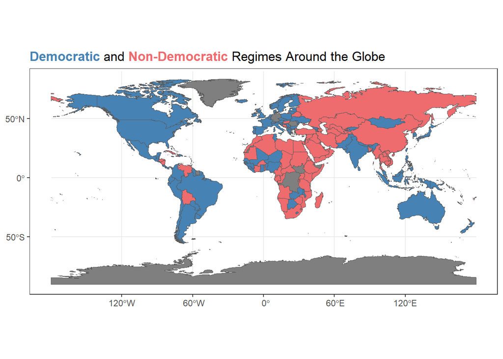

```r
world_democracy |>
  ggplot() +
  geom_sf(aes(fill = factor(is_democracy,
                            levels = c(FALSE, TRUE),
                            labels = c("No", "Yes"))),
          linewidth = 0.05) +
  labs(title = "<span style='color:steelblue'><b>Democratic</b></span> and <span style='color:#ee6b6e'><b>Non-Democratic</b></span> Regimes Around the Globe",
       alt = "World map showing countries colored by regime type. Democratic countries are shown in blue, and non-democratic countries are shown in red.") +
  scale_fill_manual(values = c("No" = "#ee6b6e",
                               "Yes" = "steelblue")) +
  theme_bw() +
  theme(legend.position = "none",
        plot.title = element_markdown())
```

## Visualization #2

```r
# load in packages needed for sankey plot

library(ggalluvial)
library(ggfittext)
library(paletteer)
```

```r
# create frequency data for sankey plot

regime_change_freq <- democracy |>
  arrange(country_code, year) |>
  group_by(country_code) |>
  mutate(post_regime = lead(regime_category)) |>
  filter((year == min(year)
          & regime_category != post_regime) |
           regime_category != post_regime)  |>
  mutate(regime_category = ifelse(regime_category %in% c("Parliamentary democracy",
                                                         "Mixed democratic",
                                                         "Presidential democracy",
                                                         "Civilian dictatorship",
                                                         "Military dictatorship",
                                                         "Royal dictatorship"),
                                  str_to_title(regime_category),
                                  "Other"),
         post_regime = ifelse(post_regime %in% c("Parliamentary democracy",
                                                 "Mixed democratic",
                                                 "Presidential democracy",
                                                 "Civilian dictatorship",
                                                 "Military dictatorship",
                                                 "Royal dictatorship"),
                              str_to_title(post_regime),
                              "Other")) |>
  ungroup(country_code) |>
  count(regime_category, post_regime)


# reorder regime categories from democratic to dictatorial

regime_change_freq <- regime_change_freq |>
  mutate(regime_category  = factor(regime_category,
                                   levels = c("Royal Dictatorship",
                                              "Military Dictatorship",
                                              "Civilian Dictatorship",
                                              "Presidential Democracy",
                                              "Mixed Democratic",
                                              "Parliamentary Democracy",
                                              "Other")),
         post_regime = factor(post_regime,
                              levels = c("Royal Dictatorship",
                                         "Military Dictatorship",
                                         "Civilian Dictatorship",
                                         "Presidential Democracy",
                                         "Mixed Democratic",
                                         "Parliamentary Democracy",
                                         "Other")))
```

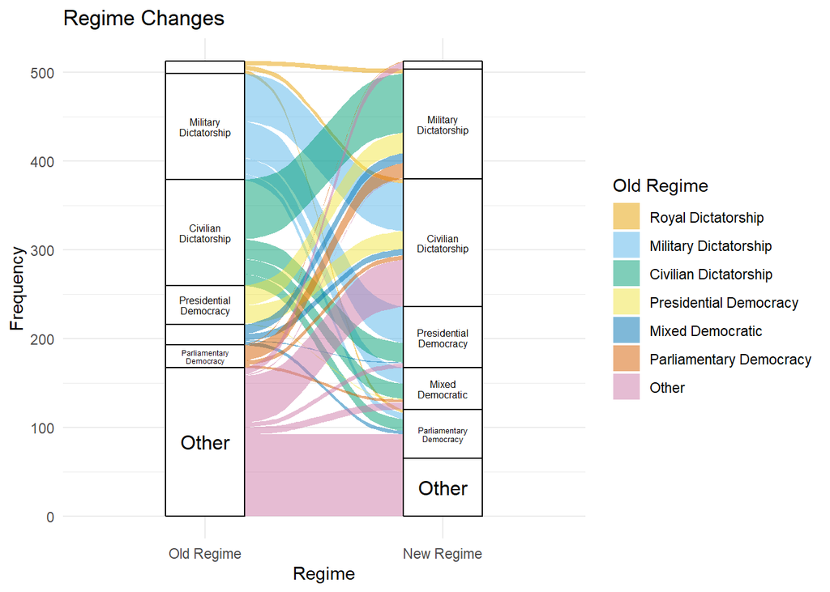

```r
# create sankey plot

regime_change_freq |>
  ggplot(aes(y = n,
             axis1 = regime_category,
             axis2 = post_regime)) +
  geom_alluvium(aes(fill = as.factor(regime_category))) +
  geom_stratum() +
  geom_fit_text(stat = "stratum",
                aes(label = str_wrap(after_stat(stratum), width = 12)),
                width = 0.25) +
  theme_minimal() +
  labs(title = "Regime Changes",
       x = "Regime",
       y = "Frequency",
       fill = "Old Regime",
       alt = "Sankey plot showing changes in political regime categories from old to new. Flows are colored by the old, or itinital, regime of the change. Regime categories for both axes include Royal Dictatorship, Military Dictatorship, Civilian Dictatorship, Presidential Democracy, Mixed Democracy, and Parliamentary Democracy (from least to most democratic). Each axis also includes an Other category comprised of non sovereign nations. Most changes to democracies are from military or civilian dictatorships.") +
  scale_x_discrete(limits = c("Old Regime", "New Regime")) +
  scale_fill_manual(values = paletteer_d("colorblindr::OkabeIto_black"))
```

## Statistical Model - Time Until Country Returns To Democracy

This survival analysis will assess the cumulative probability of *returning* to a democratic regime for those that converted from a democratic regime to a non-democratic regime (e.g., by coup d’état).

We’ll call these non-democratic intervals “spells” and measure the time until non-democratic spells are broken. Note that some countries are left-censored since we only have data going back to 1950 – those countries may have been non-democratic prior to 1950 and the model doesn’t reflect this.

```r
survival_base <- democracy |>
  arrange(country_code, year) |>
  group_by(country_code) |>
  mutate(lost_democracy = is_democracy == FALSE & lag(is_democracy, default = TRUE),
         spell_id = cumsum(lost_democracy),
         next_is_democracy = lead(is_democracy))

spell_starts <- survival_base |>
  filter(lost_democracy == TRUE) |>
  select(country_code,
         spell_id,
         region,
         is_communist,
         is_multiparty)

survival <- survival_base |>
  filter(is_democracy == FALSE) |>
  group_by(country_code, spell_id) |>
  summarize(start_year = min(year),
            end_year = max(year),
            returned_to_democracy = any(next_is_democracy == TRUE, na.rm = TRUE),
            time = end_year - start_year + 1,
            .groups = "drop")

survival <- survival |>
  left_join(spell_starts, by = c("country_code", "spell_id"))
```

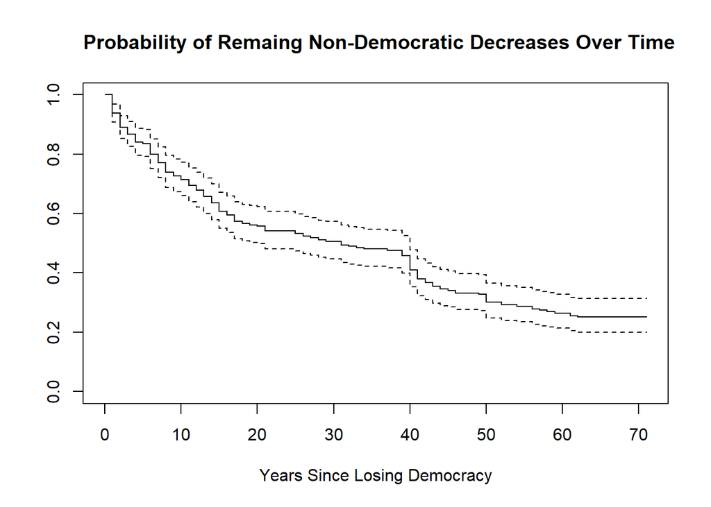

```r
library(survival)
# Survival analysis model
km <- survfit(Surv(time, returned_to_democracy) ~ 1,
              data = survival)

plot(km,
     xlab = "Years Since Losing Democracy",
     ylab = "")

title(main = "Probability of Remaing Non-Democratic Decreases Over Time", adj = 0)
```

```r
library(gtsummary)
# Cox Proportional Hazards Model
cox_model <- coxph(Surv(time, returned_to_democracy) ~
                     region +
                     is_communist +
                     is_multiparty,
                   data = survival)

#summary(cox_model)

tbl_regression(cox_model,
               exponentiate = TRUE,
               label = list(
                 is_communist ~ "Communist",
                 region ~ "Region",
                 is_multiparty ~ "Multiparty System"
                 )
               )|>
  bold_labels() |>
  as_gt() |>
  tab_style(cell_text(weight = "bold"),
            locations = cells_column_labels(everything())) |>
  tab_caption(caption = md("Cox Proportional Hazards Model Coefficent Estimates"))
```

Cox Proportional Hazards Model Coefficent Estimates

| **Characteristic** | **HR** | **95% CI** | **p-value** |
| --- | --- | --- | --- |
| Region |  |  |  |
| East Asia & Pacific | — | — |  |
| Europe & Central Asia | 2.67 | 1.23, 5.78 | 0.013 |
| Latin America & Caribbean | 3.31 | 2.08, 5.26 | <0.001 |
| Middle East & North Africa | 0.04 | 0.00, 0.26 | 0.001 |
| North America | 3.20 | 0.43, 23.8 | 0.3 |
| South Asia | 1.52 | 0.77, 2.98 | 0.2 |
| Sub-Saharan Africa | 0.88 | 0.56, 1.39 | 0.6 |
| Communist |  |  |  |
| FALSE | — | — |  |
| TRUE | 0.22 | 0.10, 0.50 | <0.001 |
| Multiparty System |  |  |  |
| FALSE | — | — |  |
| TRUE | 0.87 | 0.63, 1.21 | 0.4 |

Abbreviations: CI = Confidence Interval, HR = Hazard Ratio

There are 255 non-democratic spells, 178 of which return to democracy. The Cox Proportional Hazards Model significantly predicts “time to democracy” (p < 2e-16)

**Hazard Ratio Interpretations:**

- Countries in Europe & Central Asia return to democracy about **2.67 times faster** than the baseline region, East Asia & Pacific (p = 0.0131).
- Countries in Latin America & the Caribbean return to democracy about **3.31 times faster** than the baseline region, East Asia & Pacific (p = 4.04e-07).
- Countries in the Middle East & North Africa are about **96.4% less likely** to return to democracy than the baseline region, East Asia & Pacific (p = 0.0011).
- Communist regimes are about **78% less likely** to return to democracy compared to non-communist regimes (p = 0.0003).
- There is insufficient evidence to conclude that multiparty systems affect the likelihood of a non-democratic regime returning to democracy (p = 0.419).